# Arithmetic Expressions and Variables in R

Mohammed Shahid

5/12/2021

# 1. Revisiting Common arithmetic operators

|  | day | supply Day | item | purchase Price | selling Price | item available | item sold |
| --- | --- | --- | --- | --- | --- | --- | --- |
| 1 | 1L | TRUE | “Apple” | 10.50 | 12.10 | 200L | 0L |
| 2 | 1L | TRUE | “Mangoes” | 21.15 | 24.90 | 50L | 0L |
| 3 | 1L | TRUE | “Lemon” | 3.20 | 4.99 | 500L | 0L |
| 4 | 2L | FALSE | “Apple” | 10.50 | 12.10 | 188L | 12L |
| 5 | 2L | FALSE | “Mangoes” | 21.15 | 24.90 | 47L | 3L |
| 6 | 2L | FALSE | “Lemon” | 3.20 | 4.99 | 476L | 24L |

Write the operations that answer the following questions.

1. The total number of mangoes and lemons available in the shop on day 2 using values in the item available column.
- Sum up the number of mangoes (47L) and lemons (476L) on day 2 using the addition operator +.

```r
47+476
```

```
## [1] 523
```

2.The ratio of the purchase price of lemon against its selling price using values in purchase price and selling price columns.

- Divide the purchase price of lemon (3.20) by its selling price (4.99) using the division operator /.

```r
3.20/4.99
```

```
## [1] 0.6412826
```

# 2. Dealing with Advanced Arithmetic Operators

|  | day | supply Day | item | purchase Price | selling Price | item available | item sold |
| --- | --- | --- | --- | --- | --- | --- | --- |
| 1 | 1L | TRUE | “Apple” | 10.50 | 12.10 | 200L | 0L |
| 2 | 1L | TRUE | “Mangoes” | 21.15 | 24.90 | 50L | 0L |
| 3 | 1L | TRUE | “Lemon” | 3.20 | 4.99 | 500L | 0L |
| 4 | 2L | FALSE | “Apple” | 10.50 | 12.10 | 188L | 12L |
| 5 | 2L | FALSE | “Mangoes” | 21.15 | 24.90 | 47L | 3L |
| 6 | 2L | FALSE | “Lemon” | 3.20 | 4.99 | 476L | 24L |

Write the operations that answer the following questions.

1. Assuming the selling price of lemon is $5, how many lemons were sold if $128 is reported as the overall selling cost of a day. Use the integer division operator, %/%, to answer this question.

```r
128 %/% 5
```

```
## [1] 25
```

2. (Answer this question with TRUE or FALSE literals instead) The modulo’s operator symbol is %.

```r
FALSE
```

```
## [1] FALSE
```

# 3. Using Complex Arithmetic Expression

1. Your mission is to determine the overall cost of purchasing all fruits on day 1.

Type in the code editor the following operations.

- The total cost of purchasing apples on day 1: 10.50 * 200L.

```r
10.50 * 200L
```

```
## [1] 2100
```

- The total cost of purchasing mangoes on day 1: 21.15 * 50.

```r
21.15*50
```

```
## [1] 1057.5
```

- The total cost of purchasing lemons on day 1: 3.20 * 500.

```r
3.20*500
```

```
## [1] 1600
```

2. Compute the overall cost of purchasing all fruits on day 1, in a single expression.
- Sum up the output values from the previous question.

```r
10.50 * 200L + 21.15*50 + 3.20*500
```

```
## [1] 4757.5
```

# 4. Dealing with Operator Priority Rules

1. Your mission is to determine the overall predicted selling cost of all fruits on day 1.

Type in the code editor the following operations.

- The predicted selling cost of apples on day 1: 12.10 * 200L.

```r
12.10 * 200L
```

```
## [1] 2420
```

- The predicted selling cost of mangoes on day 1: 24.90 * 50L.

```r
24.90 * 50L
```

```
## [1] 1245
```

- The predicted selling cost of lemons on day 1: 4.99 * 500L.

```r
4.99 * 500L
```

```
## [1] 2495
```

2. Compute the overall predicted selling cost of all fruits on day 1.
- Combine the previous three simple expressions into a complex expression using the addition operator.

```r
12.10 * 200L+24.90 * 50L+4.99 * 500L
```

```
## [1] 6160
```

# 5. Identifying Expression’s data type

Use one of this character literals (“numeric” or “integer” or “logical”) to answer the following questions.

1. What is the type of the following expression: 2 * 2 * 2.

```r
"numeric"
```

```
## [1] "numeric"
```

2. What is the type of the following expression: 2L * 2L * 2.

```r
"numeric"
```

```
## [1] "numeric"
```

3. What is the type of the following expression: 2L * 2L * 2L.

```r
"integer"
```

```
## [1] "integer"
```

# 6. Dealing Variables with Naming rules

To name a variable, there are five naming rules to follow.

1. Variable names consists of letters (upper or lower case), numbers, a dot (.), or an underscore (_).
2. We can begin a variable name with a letter or a dot, but dots cannot be followed by a number.
3. We cannot begin a variable name with a number.
4. No special characters are allowed, e.g., spaces, operator’s symbols, ", parentheses.
5. We cannot use a keyword already used and interpreted by R as a variable name.

Here is a list of variable names, numbered from 1 to 5. Using naming rules, answer TRUE if the variable name is valid and FALSE otherwise. Store each answer (TRUE/FALSE) in variables named q_1 to q_5, respectively (one answer per line). An example is given in the editor.

1. .2var
2. numberOfFruit
3. apple variable
4. “var”
5. age20+

```r
q_0 <- FALSE
q_1=F
q_2=T
q_3=F
q_4=F
q_5=F
```

# 7. Updating variables

```r
total_purchase_cost=10.50 * 200L + 21.15 * 50L + 3.20 * 500L

total_selling_cost=12.10 * 200 + 24.90 * 50 + 4.99 * 500

profit_1=total_selling_cost-total_purchase_cost

print(profit_1)
```

```
## [1] 1402.5
```

# 8. Identifying variables data type

```r
q_1=class(total_purchase_cost)

q_2=class((total_selling_cost))

q_3=class(profit_1)
```

# 9. R syntax: best practice

So far we’ve used space characters between numbers and operators (+, -, *, /, ^ are operators). For instance, we’ve used 2* 2 * 2 instead of 2*2*2. But R’s syntax rules do not enforce this, so both 2 * 2 * 2 and 2*2*2 will run correctly.

You would also have noticed that we use _ to separate the words in our variable name. For instance, we’ve used total_purchase_cost instead of something else. Once again R’s syntax rules do not impose this style on you. As long as you respect the naming rules, we have learned, your code will run correctly.

The computer executes code from the first line downwards and ignores blank lines. Besides blank lines, the computer also ignores any sequence of characters that comes to the right of the # symbol. This sequence of characters that follows the # symbol is called a code comment. We can also use code comments to add information about our code.

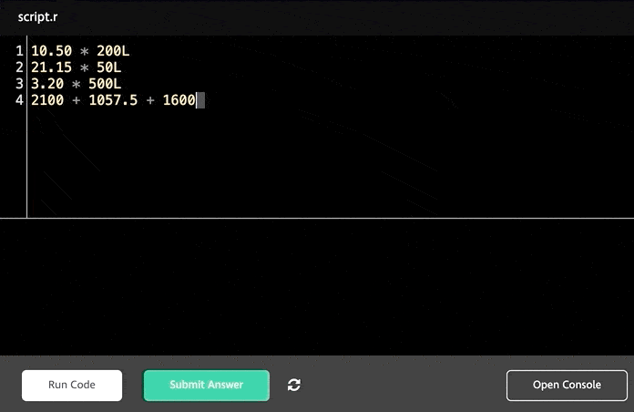

We encourage you to use those elements in your code, as this helps with readability.

# 10. Next Steps

Congratulations! You have completed the second mission of the Introduction to Programming in R course.

In this mission, you got a feel for working in our interface and learned some key basics of the R language as you analyzed data:

- Writing expressions,
- Creating and working with variables.

In the next mission, we’ll learn how to deal with logical expressions.

Advice and Challenge Our advice at the moment is to continue practicing everything we’ve learned so far.

- Get familiar with the arithmetic expressions.
- Get familiar with the variables and syntax rules we have learned.

For now, click the “Next” button below to read and download the summary of this mission. On the next screen, you’ll also be able to click the “Finish” button, which will mark this mission as complete for you.